# Survival analysis - Marriage Dissolution in the U.S.

aleniart

```r
library(survival)
library(survMisc)
library(CoxR2)
library(survminer)
library(MASS)
```

The unit of observation is the couple and the event of interest is divorce, with interview and widowhood treated as censoring events. We have three fixed covariates: education of the husband and two indicators of the couple’s ethnicity: whether the husband is black and whether the couple is mixed. The variables are:

- ID - a couple number
- heduc - education of the husband, coded <12 = less than 12 years, 12-15 = 12 to 15 years, and >15 = 16 or more years.
- heblack - coded 1 if the husband is black and 0 otherwise
- mixed - coded 1 if the husband and wife have different ethnicity (defined as black or other), 0 otherwise
- years - duration of marriage, from the date of wedding to divorce or censoring (due to widowhood or interview)
- div - the failure indicator, coded 1 for divorce and 0 for censoring

**Source: https://grodri.github.io/glms/datasets/#divorce**

## Preliminary analysis

### Dataset and basic descriptive statistics

```r
ddata <- read.table("divorce_dataset.csv", header = TRUE, sep = ",",dec=".")
ddata$heduc <- as.factor(ddata$heduc)
ddata$heblack <- as.factor(ddata$heblack)
ddata$mixed <- as.factor(ddata$mixed)
ddata$div <- as.factor(ddata$div)
summary(ddata)
```

```
##        id          heduc      heblack  mixed        years        div
##  Min.   :    9   <12  :1288   0:2626   0:2730   Min.   : 0.079   0:2339
##  1st Qu.: 3572   >15  : 428   1: 745   1: 641   1st Qu.: 6.485   1:1032
##  Median : 7130   12-15:1655                     Median :14.497
##  Mean   : 7762                                  Mean   :18.410
##  3rd Qu.:11908                                  3rd Qu.:26.141
##  Max.   :17302                                  Max.   :73.068
```

Referring to the above statistics, it can be seen that no missing data has been identified.

Histogram for the variable “years”.

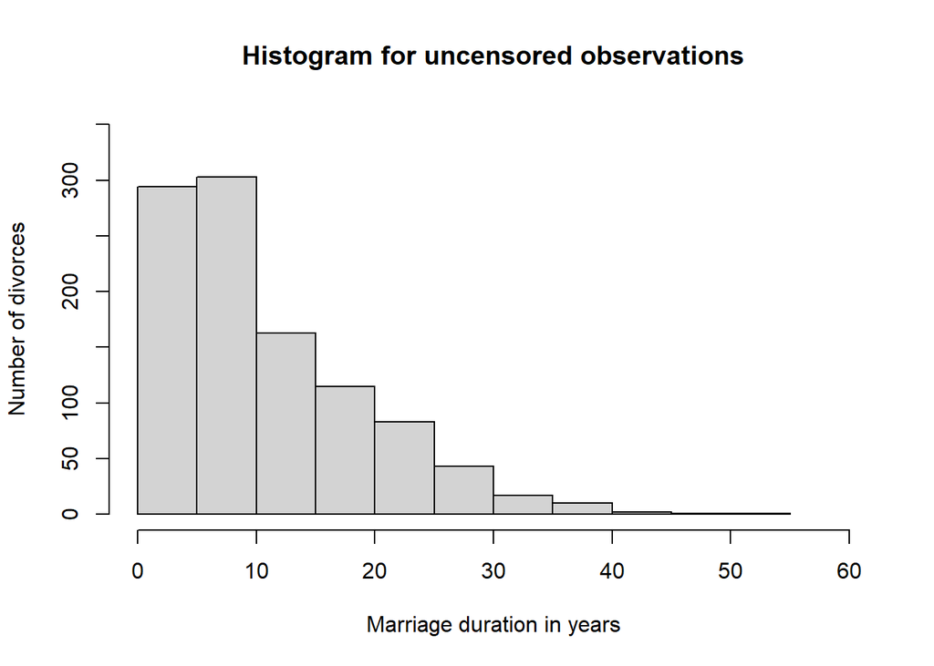

```r
hist(ddata$years[ddata$div==1], xlab="Marriage duration in years", ylab="Number of divorces",
     main = "Histogram for uncensored observations",
     ylim=c(0,350),
     xlim=c(0,60))
```

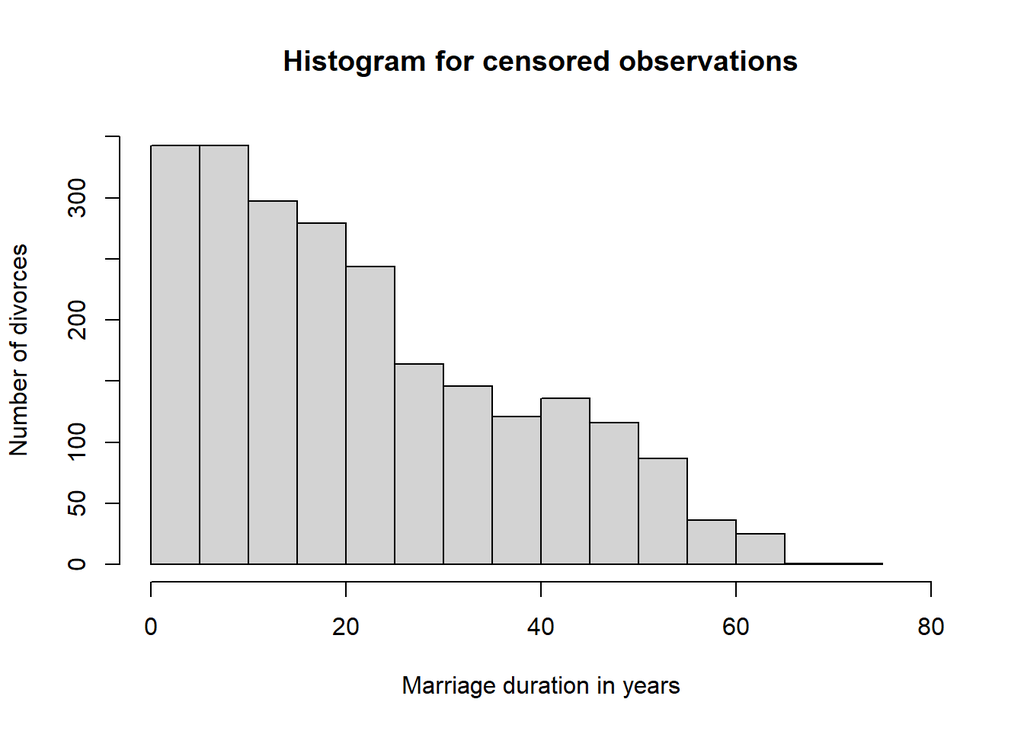

```r
hist(ddata$years[ddata$div==0], xlab="Marriage duration in years", ylab="Number of divorces",
     main = "Histogram for censored observations",
     ylim=c(0,350),
     xlim=c(0,80))
```

The histograms represent a quantitative variable indicating the duration of marriage. The first one (uncensored observations) indicates that a significant number of marriages lasted less than 10 years, while a negligible amount lasted more than 35 years. For censored observations, the data is more evenly distributed.

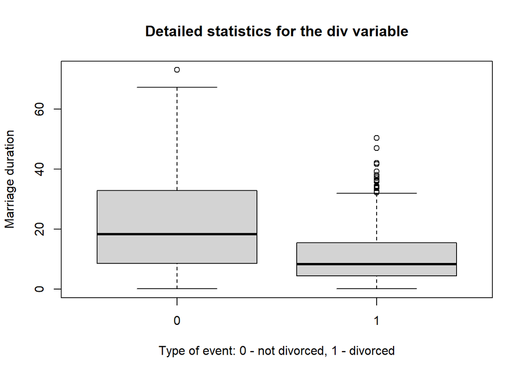

```r
boxplot(ddata$years~ddata$div, main='Detailed statistics for the div variable', xlab= 'Type of event: 0 - not divorced, 1 - divorced', ylab='Marriage duration')
```

```r
by(ddata$years, ddata$div, summary)
```

```
## ddata$div: 0
##    Min. 1st Qu.  Median    Mean 3rd Qu.    Max.
##   0.079   8.534  18.237  21.786  32.816  73.068
## ------------------------------------------------------------
## ddata$div: 1
##    Min. 1st Qu.  Median    Mean 3rd Qu.    Max.
##   0.101   4.439   8.348  10.759  15.451  50.379
```

Couples who have experienced divorce tend to have significantly shorter average durations (median as well) of marriage compared to couples who have not yet reported a divorce.

Bar plot for the variable “heduc”.

[figure not shown]

```r
barplot(table(ddata$heduc),
        col = c("yellow","red","green"), horiz = TRUE,
        names.arg = c("<12", "12-15",">=16" ),
        xlab = "Number of men", ylab = "Years of education",
        main = "Husbend's years of education", xlim = c(0,2000))
```

In addition, we will look at the husband’s years of education broken down into the occurrence of divorce or not.

[figure not shown]

```r
par(mfrow=c(1,2))  # Setting up the layout for one row and two columns of plots

# First plot for divorces (div == 1)
barplot(table(ddata$heduc[ddata$div==1]),
        col = c("lightyellow","lightgreen","red"),
        names.arg = c("<12", "12-15",">=16" ),
        xlab = "Number of divorced men", ylim=c(0,1500))
text(1:3, table(ddata$heduc[ddata$div == 1]), labels = table(ddata$heduc[ddata$div == 1]), pos = 3)

# Second plot for censoring (div == 0)
barplot(table(ddata$heduc[ddata$div == 0]),
        col = c("lightyellow","red","lightgreen"),
        names.arg = c("<12", "12-15",">=16" ), ylim=c(0,1500),
        xlab = "Number of non-divorced men",
        axes=F)
text(1:3, table(ddata$heduc[ddata$div == 0]), labels = table(ddata$heduc[ddata$div == 0]), pos = 3)
```

```r
par(mfrow=c(1,1))  # Restoring the default plot layout
```

Comparison of marriage duration to mixed ethnicity and skin color.

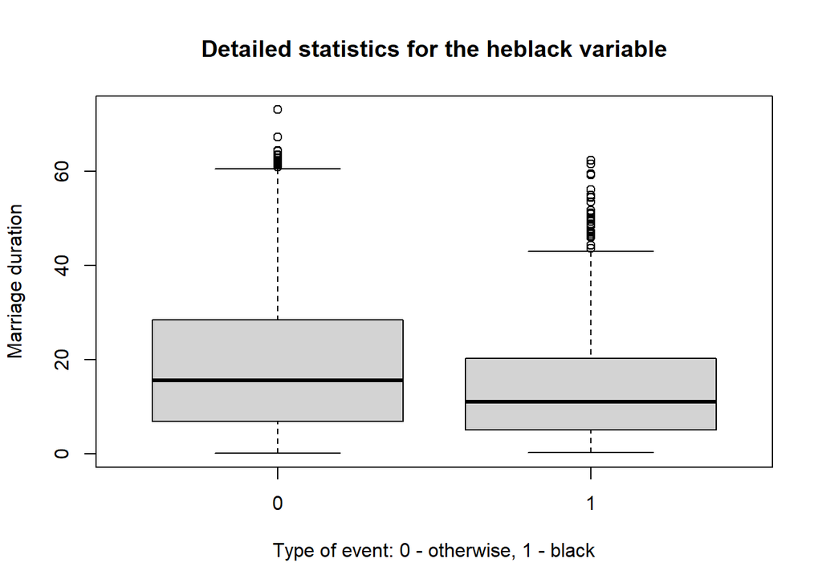

```r
#heblack
boxplot(ddata$years~ddata$heblack, main='Detailed statistics for the heblack variable', xlab='Type of event: 0 - otherwise, 1 - black', ylab='Marriage duration')
```

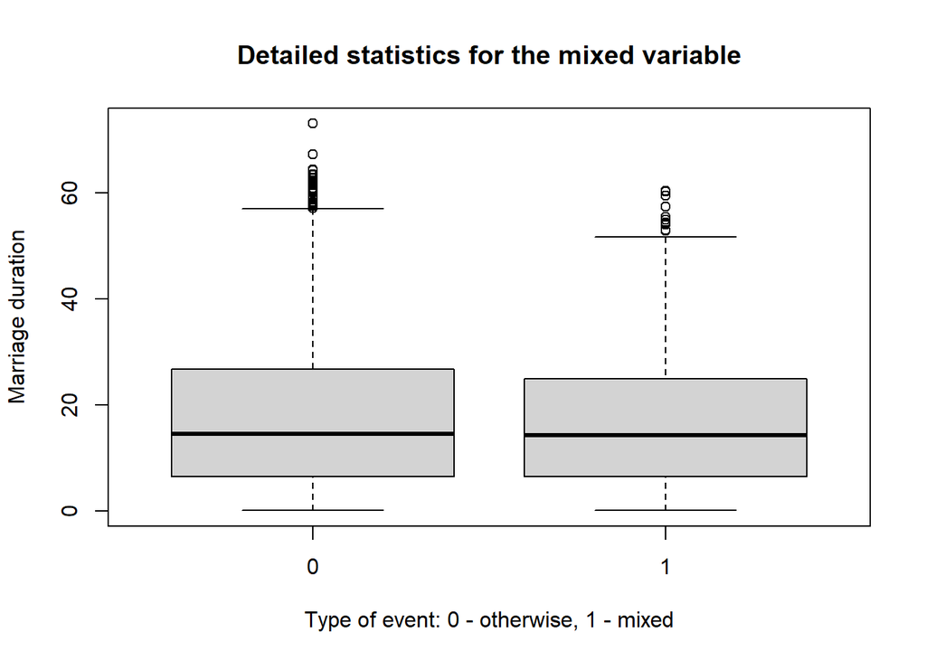

```r
#mixed
boxplot(ddata$years~ddata$mixed, main='Detailed statistics for the mixed variable', xlab='Type of event: 0 - otherwise, 1 - mixed', ylab='Marriage duration')
```

```r
#overall summary
by(ddata$years, ddata$heblack, summary)
```

```
## ddata$heblack: 0
##    Min. 1st Qu.  Median    Mean 3rd Qu.    Max.
##   0.079   6.882  15.595  19.487  28.340  73.068
## ------------------------------------------------------------
## ddata$heblack: 1
##    Min. 1st Qu.  Median    Mean 3rd Qu.    Max.
##   0.222   5.032  11.017  14.615  20.252  62.338
```

```r
by(ddata$years, ddata$mixed, summary)
```

```
## ddata$mixed: 0
##    Min. 1st Qu.  Median    Mean 3rd Qu.    Max.
##   0.079   6.497  14.538  18.643  26.738  73.068
## ------------------------------------------------------------
## ddata$mixed: 1
##    Min. 1st Qu.  Median    Mean 3rd Qu.    Max.
##   0.167   6.418  14.319  17.419  24.961  60.353
```

Overall, the statistics are very similar for both variables. However, in the case of the ‘heblack’ variable and the ‘black’ variant, the average marriage duration seems to be slightly lower than for the other variants.

## Survival analysis

### Kaplan-Meier and Nelson-Aalen estimators

**Kaplan-Meier estimator:**

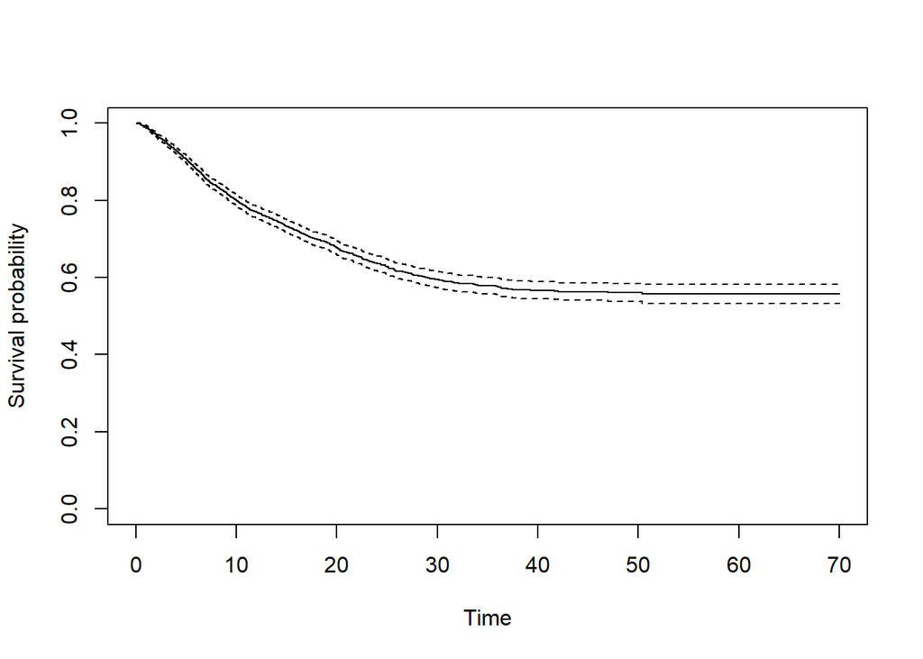

```r
km <- survfit(Surv(years, div) ~ 1, conf.type="log", data=ddata)
#summary(km)
plot(km, xlim= c(0,70), xlab="Time", ylab="Survival probability")
```

**Cumulative hazards function graph:**

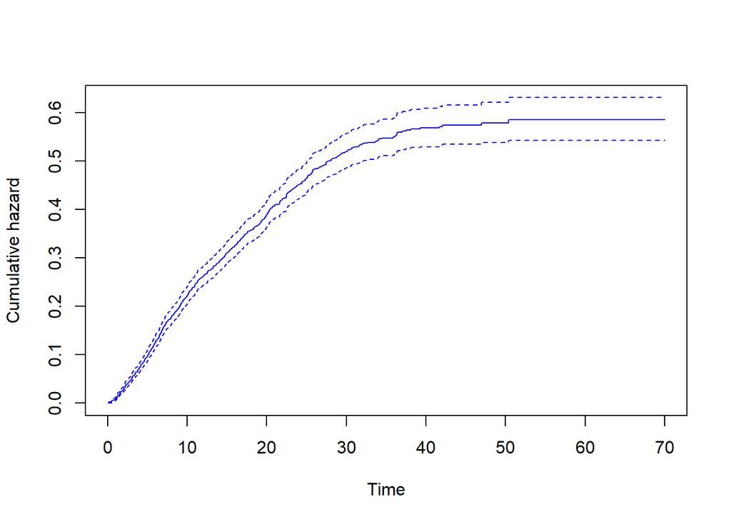

```r
plot(km, xlim= c(0,70), fun="cumhaz",xlab="Time", ylab="Cumulative hazard")
lines(km, fun="cumhaz",col="blue")
```

**Nelson-Aalen estimator:**

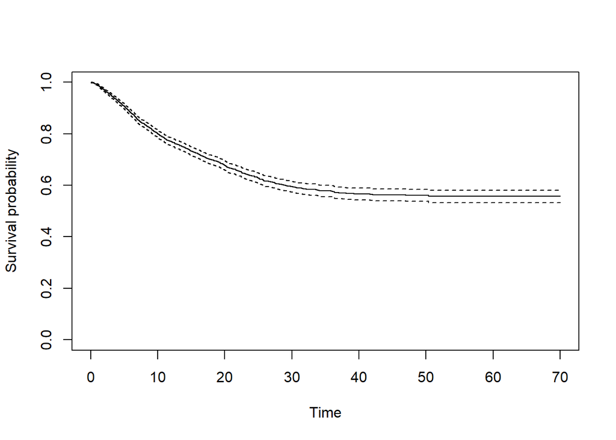

```r
Nels=survfit(Surv(years, div) ~ 1, conf.type ="log-log", type="fleming-harrington", data=ddata)
#summary(Nels)
plot(Nels, xlim= c(0,70), xlab="Time", ylab="Survival probability")
```

**Cumulative hazards function graph:**

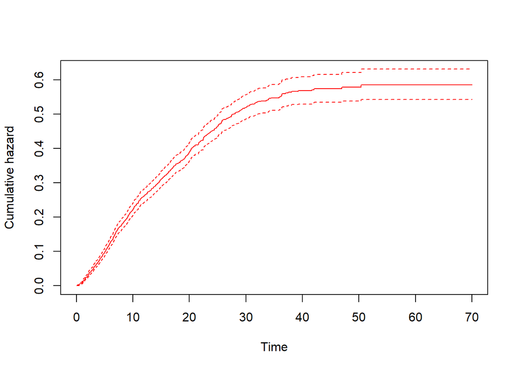

```r
plot(Nels, xlim= c(0,70), fun="cumhaz",xlab="Time", ylab="Cumulative hazard")
lines(Nels, fun="cumhaz",col="red")
```

### Survival curves (Kaplan-Meier estimators)

**Husband’s education variable:**

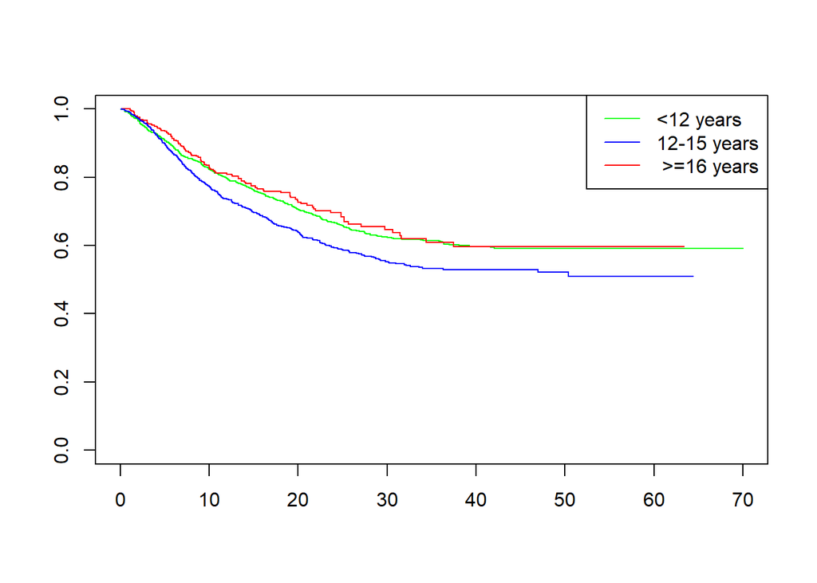

```r
km = survfit(Surv(years, div) ~ heduc, conf.type="plain", data=ddata)
#summary(km)
plot(km, xlim= c(0,70), col=c("green","red","blue"))
legend("topright", c("<12 years", "12-15 years"," >=16 years"),
       lty=1, col=c("green","blue","red"),bty="c")
```

Regarding the impact of the husband’s education level, the class corresponding to “12-15 years” has a lower probability of survival. Marriages in which the husband had less than 12 years of education lasted longer.

**Husband’s skin color variable:**

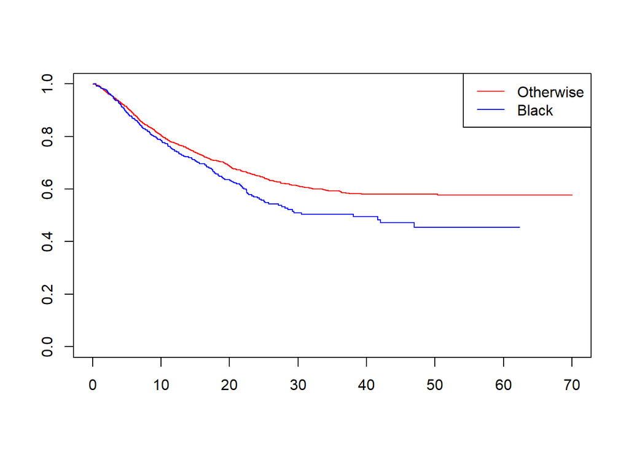

```r
km = survfit(Surv(years, div) ~ heblack, conf.type="plain", data=ddata)
#summary(km)
plot(km, xlim= c(0,70), col=c("red","blue"))
legend("topright", c("Otherwise", "Black"),
       lty=1, col=c("red","blue"),bty="c")
```

The graph above indicates that the probability of survival if the “husband is black” in a marriage is lower than if the “husband is not black”. Moreover, marriages in which the husband’s skin color was other than black lasted longer

**Mixed-ethnic marriage variable:**

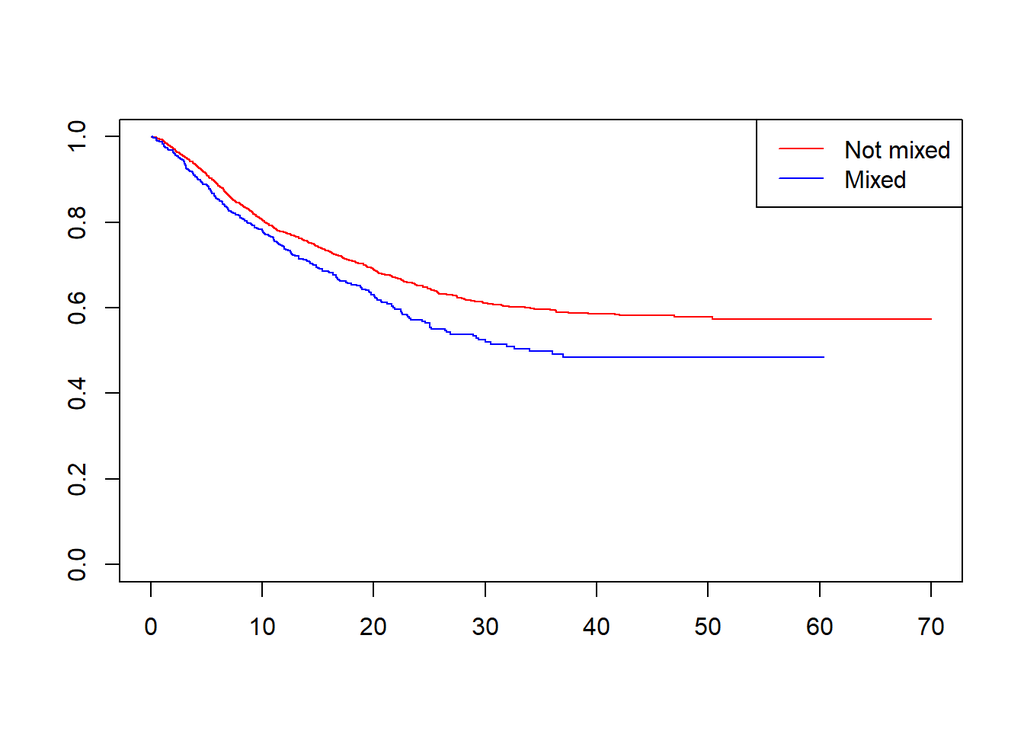

```r
km = survfit(Surv(years, div) ~ mixed, conf.type="plain", data=ddata)
#summary(km)
plot(km,  xlim= c(0,70), col=c("red","blue"))
legend("topright", c("Not mixed", "Mixed"),
       lty=1, col=c("red","blue"),bty="c")
```

The graph above indicates that the probability of survival if the couple is mixed ethnicity is lower than if the couple is not. Additionally, marriages in which the spouses were the same ethnicity lasted longer.

### Tests for comparing survival curves

**Assumptions**

**α** = 0.05

*Log-rank test hypothesis:*

**H0:** The two survival curves are similar.

**H1:** The two survival curves are not similar.

*Peto-Peto test hypothesis:*

**H0:** The hazard functions of the groups being compared are proportional over time.

**H1:** The hazard functions of the groups being compared are not proportional over time.

**Husband’s education variable:**

```r
survdiff(Surv(years, div) ~ heduc,rho=0,data=ddata) #Log-rank test
```

```
## Call:
## survdiff(formula = Surv(years, div) ~ heduc, data = ddata, rho = 0)
##
##                N Observed Expected (O-E)^2/E (O-E)^2/V
## heduc=<12   1288      393      436      4.30      7.51
## heduc=>15    428      110      132      3.73      4.28
## heduc=12-15 1655      529      463      9.26     16.93
##
##  Chisq= 17.4  on 2 degrees of freedom, p= 2e-04
```

```r
survdiff(Surv(years, div) ~ heduc,rho=1,data=ddata) #Peto-Peto test
```

```
## Call:
## survdiff(formula = Surv(years, div) ~ heduc, data = ddata, rho = 1)
##
##                N Observed Expected (O-E)^2/E (O-E)^2/V
## heduc=<12   1288    317.6      352      3.32      6.89
## heduc=>15    428     89.3      109      3.51      4.81
## heduc=12-15 1655    438.1      384      7.51     16.56
##
##  Chisq= 17.2  on 2 degrees of freedom, p= 2e-04
```

```r
pairwise_survdiff(Surv(years, div)~heduc,data=ddata, rho=0, p.adjust.method ="holm")
```

```
##
##  Pairwise comparisons using Log-Rank test
##
## data:  ddata and heduc
##
##       <12    >15
## >15   0.4943 -
## 12-15 0.0012 0.0047
##
## P value adjustment method: holm
```

```r
heducdata<-ddata$heduc
heducdata[which(heducdata=='>15')]='12-15'
ddata$heduc=heducdata
pairwise_survdiff(Surv(years, div)~heduc,data=ddata, rho=0, p.adjust.method ="holm")
```

```
##
##  Pairwise comparisons using Log-Rank test
##
## data:  ddata and heduc
##
##       <12
## 12-15 0.0061
##
## P value adjustment method: holm
```

**Husband’s skin color variable:**

```r
survdiff(Surv(years, div) ~ heblack,rho=0,data=ddata) #test Log-rank
```

```
## Call:
## survdiff(formula = Surv(years, div) ~ heblack, data = ddata,
##     rho = 0)
##
##              N Observed Expected (O-E)^2/E (O-E)^2/V
## heblack=0 2626      802      839      1.62      8.69
## heblack=1  745      230      193      7.03      8.69
##
##  Chisq= 8.7  on 1 degrees of freedom, p= 0.003
```

```r
survdiff(Surv(years, div) ~ heblack,rho=1,data=ddata) #test Peto-Peto
```

```
## Call:
## survdiff(formula = Surv(years, div) ~ heblack, data = ddata,
##     rho = 1)
##
##              N Observed Expected (O-E)^2/E (O-E)^2/V
## heblack=0 2626      656      684      1.13      6.99
## heblack=1  745      189      161      4.77      6.99
##
##  Chisq= 7  on 1 degrees of freedom, p= 0.008
```

**Conclusions:** In both the log-rank test and the Peto-Peto test, the p-value is below the chosen alpha level. This indicates that the two survival curves are not similar, and the hazard functions of the compared groups are not proportional over time. Moreover, the ‘heblack’ variable is considered as a significant predictor.

**Mixed-ethnic marriage variable:**

```r
survdiff(Surv(years, div) ~ mixed,rho=0,data=ddata) #test Log-rank
```

```
## Call:
## survdiff(formula = Surv(years, div) ~ mixed, data = ddata, rho = 0)
##
##            N Observed Expected (O-E)^2/E (O-E)^2/V
## mixed=0 2730      797      839      2.12      11.3
## mixed=1  641      235      193      9.22      11.3
##
##  Chisq= 11.3  on 1 degrees of freedom, p= 8e-04
```

```r
survdiff(Surv(years, div) ~ mixed,rho=1,data=ddata) #test Peto-Peto
```

```
## Call:
## survdiff(formula = Surv(years, div) ~ mixed, data = ddata, rho = 1)
##
##            N Observed Expected (O-E)^2/E (O-E)^2/V
## mixed=0 2730      653      686      1.65      10.5
## mixed=1  641      192      159      7.15      10.5
##
##  Chisq= 10.5  on 1 degrees of freedom, p= 0.001
```

### Verification of the proportionality assumption

**Assumptions**

**α** = 0.05

*Proportionality test hypothesis:*

**H0:** The effect of each variable on the risk of the event remains constant over time.

**H1:** The effect of at least one variable on the risk of the event changes over time.

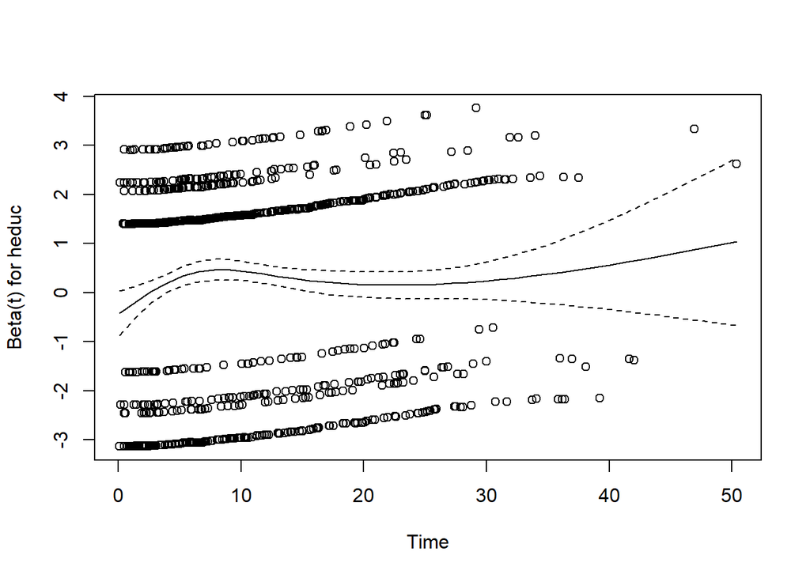

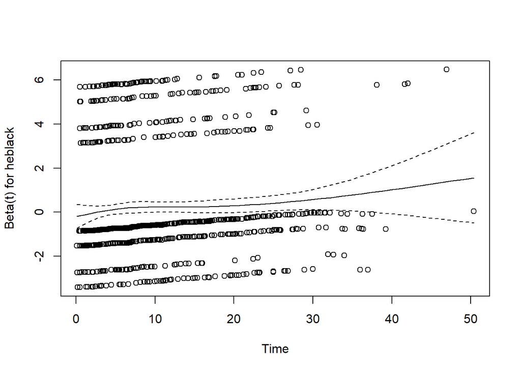

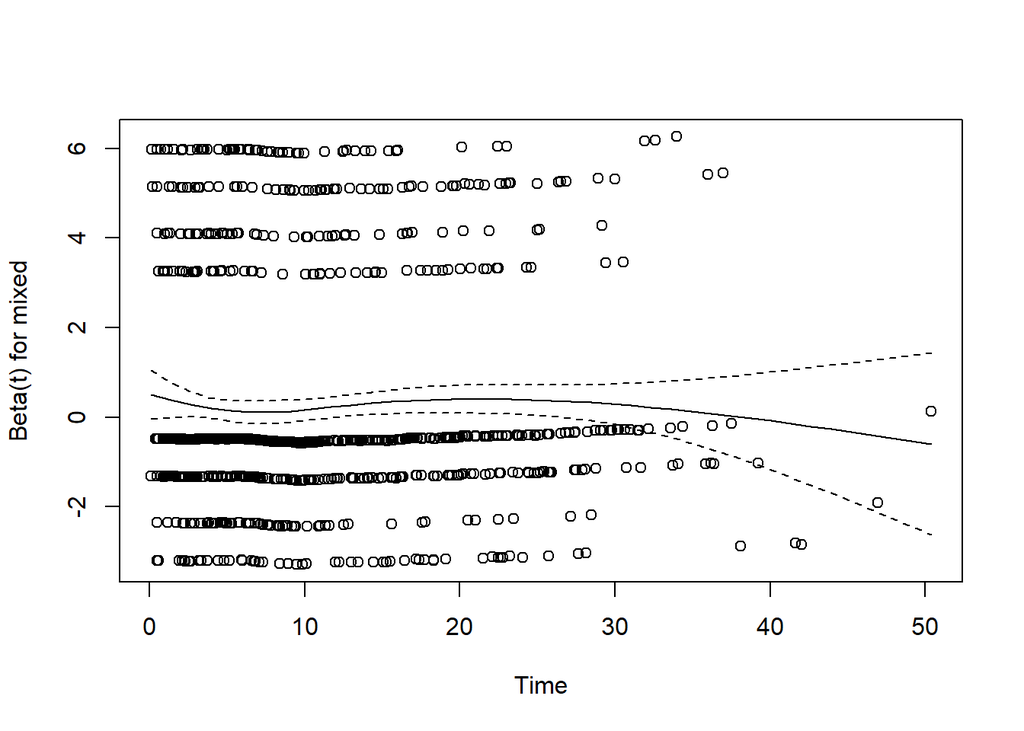

```r
Cox=coxph(Surv(years, div)~heduc+heblack+mixed,data=ddata)
proportionality=cox.zph(Cox,transform="identity")
plot(proportionality)
```

```r
print(proportionality)
```

```
##         chisq df     p
## heduc   0.143  1 0.705
## heblack 5.108  1 0.024
## mixed   0.667  1 0.414
## GLOBAL  5.928  3 0.115
```

**Conclusions:** The p-value is above the chosen alpha level for the ‘heduc’ and ‘mixed’ variables. Therefore, it can be assumed that only these two variables satisfy the proportionality assumption.

### Outliers identification

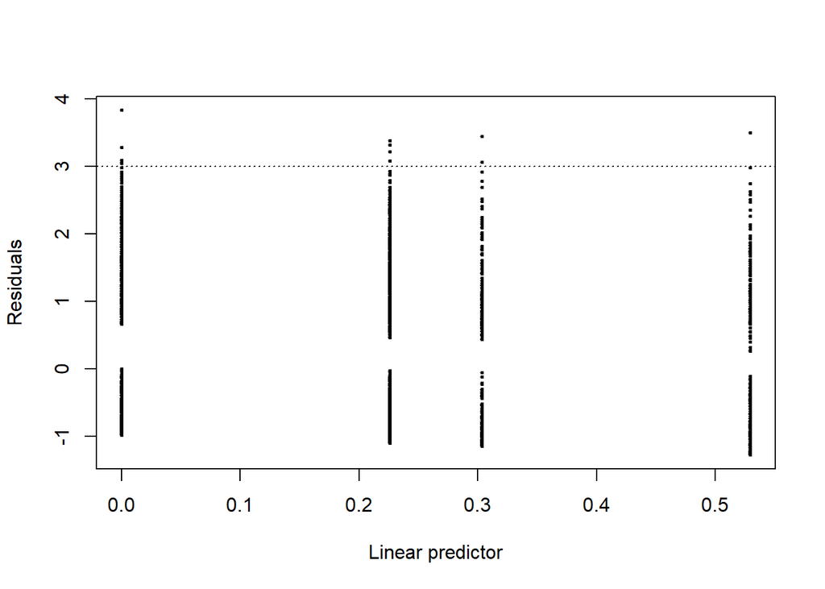

```r
COX<-coxph(Surv(years, div)~heduc+mixed, data=ddata)
deviance=residuals(COX,type="deviance")
s=COX$linear.predictors
plot(s,deviance,xlab="Linear predictor",ylab="Residuals",cex=0.5, pch=20)
abline(h=3,lty=3)
```

```r
ddata$deviance=deviance
c1=which(ddata$deviance>3) # 13 outliers
```

Above the threshold, there are 13 observations that can be considered as outliers.

In further analysis outliers will be excluded from the dataset.

### Final Cox model

```r
Cox2<-coxph(Surv(years, div)~heduc+mixed, data=ddata2)

stepAIC(Cox2,direction="backward")
```

```
## Start:  AIC=15457.4
## Surv(years, div) ~ heduc + mixed
##
##         Df   AIC
## <none>     15457
## - heduc  1 15469
## - mixed  1 15471
```

```
## Call:
## coxph(formula = Surv(years, div) ~ heduc + mixed, data = ddata2)
##
##               coef exp(coef) se(coef)     z        p
## heduc12-15 0.24187   1.27363  0.06634 3.646 0.000266
## mixed      0.30717   1.35957  0.07637 4.022 5.76e-05
##
## Likelihood ratio test=24.16  on 2 df, p=5.677e-06
## n= 3358, number of events= 1019
```

**Summary**

- The Cox Hazard Model proved to be successful - the assumption of proportionality was met.
- All predictors appeared to be relevent, however, the ‘heduc’ variable required grouping.
- It can be inferred that the model structure was appropriately chosen for the dataset.

**Model interpretation:**

- `Heduc12-15`: At any given time, the risk of divorce in marriages where the husband has from 12 to 15 years of education is 1.274 (27.4%) times higher than in marriages where the husband has less than 12 years of education.
- `Mixed`: At any given time, the risk of divorce in marriages of mixed ethnicities is 1.36 (35%) times higher than in marriages of the same ethnic background.